# State Frequencies and Chi-square Mosaics

# Purpose

`plot_state_frequencies()` and `mosaic_plot()` look similar at first glance because both use rectangles. They answer different questions.

`plot_state_frequencies()` asks: what states make up the data?

`mosaic_plot()` asks: which count cells are higher or lower than expected under independence?

# State Frequencies for One Network

```
#> State frequencies (style = marimekko, source = netobject)
#>   Total events: 1,870  |  Groups: 1  |  States: 3
#>
#> Per-group totals
#>     group  events  share
#>     all    1,870   100.0%
#>
#> Per-state proportions (within group)
#>     group  state       count  share
#>     all    Average     813    43.5%
#>     all    Active      703    37.6%
#>     all    Disengaged  354    18.9%
```

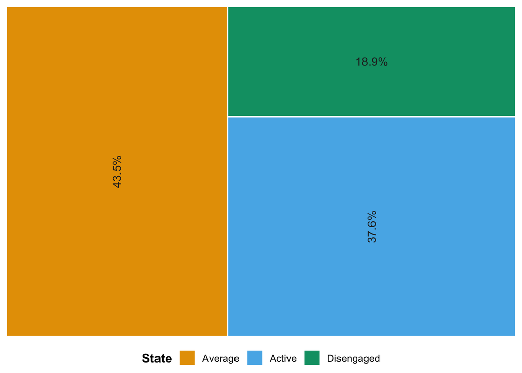

```r
data(trajectories)

net <- build_network(
  as.data.frame(trajectories),
  method = "relative",
  format = "wide"
)

freq <- plot_state_frequencies(net)
freq
```

The returned object contains the plot and the tidy table.

```r
as.data.frame(freq)
```

| group | state | count | proportion |
| --- | --- | --- | --- |
| all | Average | 813 | 0.4347594 |
| all | Active | 703 | 0.3759358 |
| all | Disengaged | 354 | 0.1893048 |

The table is often the clearest place to read exact counts and proportions.

# State Frequencies by Group

```
#> State frequencies (style = marimekko, source = netobject_group)
#>   Total events: 27,533  |  Groups: 3  |  States: 9
#>
#> Per-group totals
#>     group  events  share
#>     A      12,390  45.0%
#>     B       9,626  35.0%
#>     C       5,517  20.0%
#>
#> Per-state proportions (within group)
#>     group  state       count  share
#>     A      consensus   3,298  26.6%
#>     A      plan        2,805  22.6%
#>     A      discuss     1,960  15.8%
#>     A      emotion     1,517  12.2%
#>     A      cohesion      923  7.4%
#>     A      coregulate    855  6.9%
#>     A      monitor       602  4.9%
#>     A      synthesis     290  2.3%
#>     A      adapt         140  1.1%
#>     B      plan        2,445  25.4%
#>     B      consensus   2,226  23.1%
#>     B      discuss     1,453  15.1%
#>     B      emotion       995  10.3%
#>     B      coregulate    817  8.5%
#>     B      cohesion      590  6.1%
#>     B      monitor       565  5.9%
#>     B      synthesis     274  2.8%
#>     B      adapt         261  2.7%
#>     C      plan        1,373  24.9%
#>     C      consensus   1,273  23.1%
#>     C      discuss       854  15.5%
#>     C      emotion       563  10.2%
#>     C      coregulate    461  8.4%
#>     C      monitor       349  6.3%
#>     C      cohesion      326  5.9%
#>     C      synthesis     165  3.0%
#>     C      adapt         153  2.8%
```

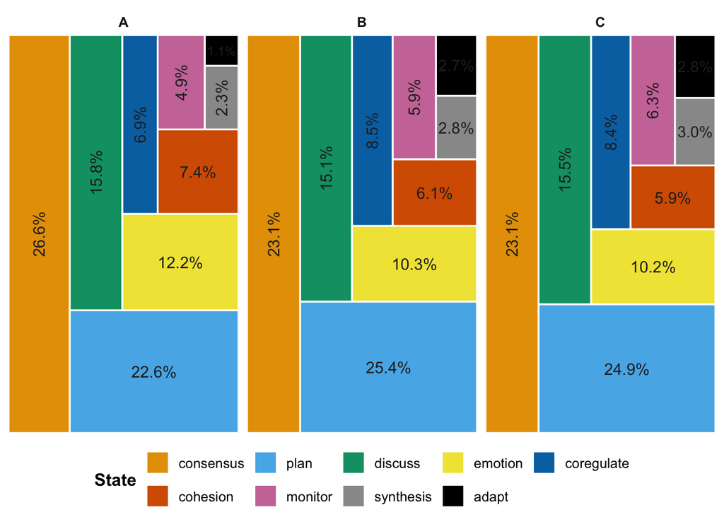

```r
data(group_regulation_long)

course_net <- build_network(
  group_regulation_long,
  method = "relative",
  actor = "Actor",
  action = "Action",
  time = "Time",
  group = "Course"
)

plot_state_frequencies(course_net)
```

The treemap emphasizes composition. A large tile means a state accounts for a large share of that group.

Use bars when exact comparison by length is easier.

```
#> State frequencies (style = bars, source = netobject_group)
#>   Total events: 27,533  |  Groups: 3  |  States: 9
#>
#> Per-group totals
#>     group  events  share
#>     A      12,390  45.0%
#>     B       9,626  35.0%
#>     C       5,517  20.0%
#>
#> Per-state proportions (within group)
#>     group  state       count  share
#>     A      consensus   3,298  26.6%
#>     A      plan        2,805  22.6%
#>     A      discuss     1,960  15.8%
#>     A      emotion     1,517  12.2%
#>     A      cohesion      923  7.4%
#>     A      coregulate    855  6.9%
#>     A      monitor       602  4.9%
#>     A      synthesis     290  2.3%
#>     A      adapt         140  1.1%
#>     B      plan        2,445  25.4%
#>     B      consensus   2,226  23.1%
#>     B      discuss     1,453  15.1%
#>     B      emotion       995  10.3%
#>     B      coregulate    817  8.5%
#>     B      cohesion      590  6.1%
#>     B      monitor       565  5.9%
#>     B      synthesis     274  2.8%
#>     B      adapt         261  2.7%
#>     C      plan        1,373  24.9%
#>     C      consensus   1,273  23.1%
#>     C      discuss       854  15.5%
#>     C      emotion       563  10.2%
#>     C      coregulate    461  8.4%
#>     C      monitor       349  6.3%
#>     C      cohesion      326  5.9%
#>     C      synthesis     165  3.0%
#>     C      adapt         153  2.8%
```

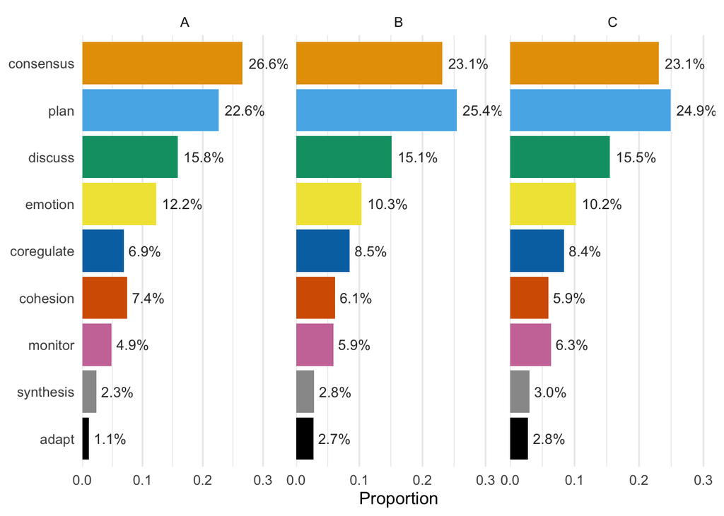

```r
plot_state_frequencies(course_net, style = "bars")
```

Switch the metric when counts matter more than proportions.

```
#> State frequencies (style = bars, source = netobject_group)
#>   Total events: 27,533  |  Groups: 3  |  States: 9
#>
#> Per-group totals
#>     group  events  share
#>     A      12,390  45.0%
#>     B       9,626  35.0%
#>     C       5,517  20.0%
#>
#> Per-state proportions (within group)
#>     group  state       count  share
#>     A      consensus   3,298  26.6%
#>     A      plan        2,805  22.6%
#>     A      discuss     1,960  15.8%
#>     A      emotion     1,517  12.2%
#>     A      cohesion      923  7.4%
#>     A      coregulate    855  6.9%
#>     A      monitor       602  4.9%
#>     A      synthesis     290  2.3%
#>     A      adapt         140  1.1%
#>     B      plan        2,445  25.4%
#>     B      consensus   2,226  23.1%
#>     B      discuss     1,453  15.1%
#>     B      emotion       995  10.3%
#>     B      coregulate    817  8.5%
#>     B      cohesion      590  6.1%
#>     B      monitor       565  5.9%
#>     B      synthesis     274  2.8%
#>     B      adapt         261  2.7%
#>     C      plan        1,373  24.9%
#>     C      consensus   1,273  23.1%
#>     C      discuss       854  15.5%
#>     C      emotion       563  10.2%
#>     C      coregulate    461  8.4%
#>     C      monitor       349  6.3%
#>     C      cohesion      326  5.9%
#>     C      synthesis     165  3.0%
#>     C      adapt         153  2.8%
```

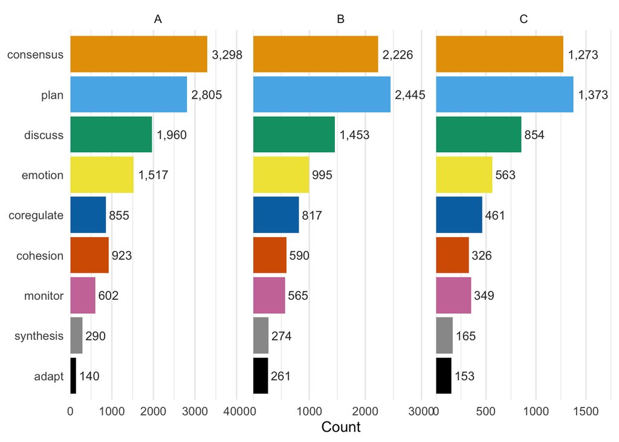

```r
plot_state_frequencies(
  course_net,
  style = "bars",
  metric = "freq",
  label = "freq"
)
```

# Labels and Legends

```
#> State frequencies (style = marimekko, source = netobject_group)
#>   Total events: 27,533  |  Groups: 3  |  States: 9
#>
#> Per-group totals
#>     group  events  share
#>     A      12,390  45.0%
#>     B       9,626  35.0%
#>     C       5,517  20.0%
#>
#> Per-state proportions (within group)
#>     group  state       count  share
#>     A      consensus   3,298  26.6%
#>     A      plan        2,805  22.6%
#>     A      discuss     1,960  15.8%
#>     A      emotion     1,517  12.2%
#>     A      cohesion      923  7.4%
#>     A      coregulate    855  6.9%
#>     A      monitor       602  4.9%
#>     A      synthesis     290  2.3%
#>     A      adapt         140  1.1%
#>     B      plan        2,445  25.4%
#>     B      consensus   2,226  23.1%
#>     B      discuss     1,453  15.1%
#>     B      emotion       995  10.3%
#>     B      coregulate    817  8.5%
#>     B      cohesion      590  6.1%
#>     B      monitor       565  5.9%
#>     B      synthesis     274  2.8%
#>     B      adapt         261  2.7%
#>     C      plan        1,373  24.9%
#>     C      consensus   1,273  23.1%
#>     C      discuss       854  15.5%
#>     C      emotion       563  10.2%
#>     C      coregulate    461  8.4%
#>     C      monitor       349  6.3%
#>     C      cohesion      326  5.9%
#>     C      synthesis     165  3.0%
#>     C      adapt         153  2.8%
```

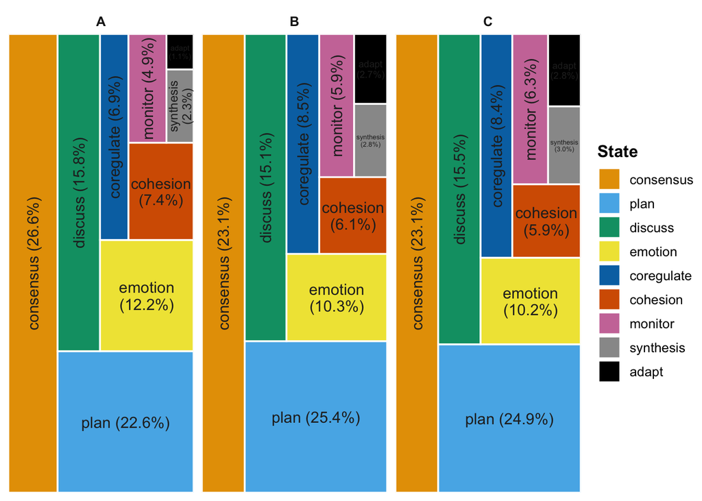

```r
plot_state_frequencies(course_net, label = "all", legend = "right")
```

For dense panels, remove labels and let the legend carry the names.

```
#> State frequencies (style = marimekko, source = netobject_group)
#>   Total events: 27,533  |  Groups: 3  |  States: 9
#>
#> Per-group totals
#>     group  events  share
#>     A      12,390  45.0%
#>     B       9,626  35.0%
#>     C       5,517  20.0%
#>
#> Per-state proportions (within group)
#>     group  state       count  share
#>     A      consensus   3,298  26.6%
#>     A      plan        2,805  22.6%
#>     A      discuss     1,960  15.8%
#>     A      emotion     1,517  12.2%
#>     A      cohesion      923  7.4%
#>     A      coregulate    855  6.9%
#>     A      monitor       602  4.9%
#>     A      synthesis     290  2.3%
#>     A      adapt         140  1.1%
#>     B      plan        2,445  25.4%
#>     B      consensus   2,226  23.1%
#>     B      discuss     1,453  15.1%
#>     B      emotion       995  10.3%
#>     B      coregulate    817  8.5%
#>     B      cohesion      590  6.1%
#>     B      monitor       565  5.9%
#>     B      synthesis     274  2.8%
#>     B      adapt         261  2.7%
#>     C      plan        1,373  24.9%
#>     C      consensus   1,273  23.1%
#>     C      discuss       854  15.5%
#>     C      emotion       563  10.2%
#>     C      coregulate    461  8.4%
#>     C      monitor       349  6.3%
#>     C      cohesion      326  5.9%
#>     C      synthesis     165  3.0%
#>     C      adapt         153  2.8%
```

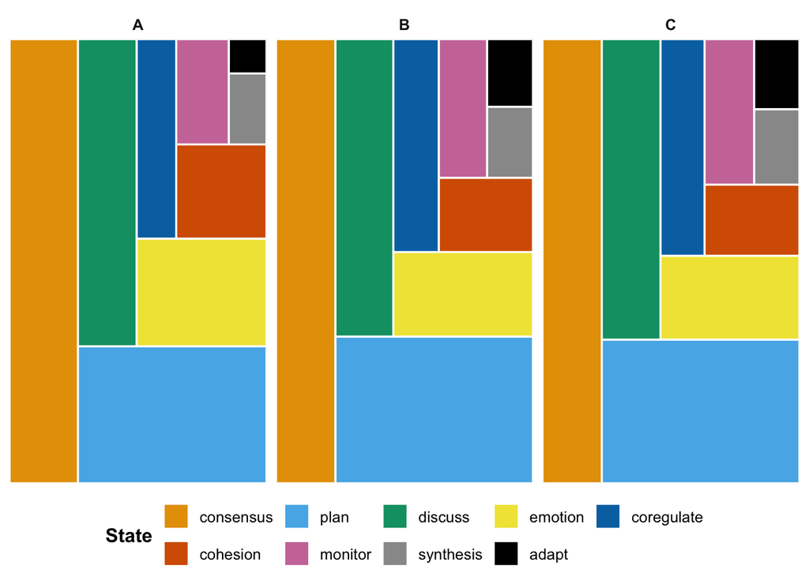

```r
plot_state_frequencies(course_net, label = "none", legend = "bottom")
```

Abbreviation helps when names collide.

```
#> State frequencies (style = marimekko, source = netobject_group)
#>   Total events: 27,533  |  Groups: 3  |  States: 9
#>
#> Per-group totals
#>     group  events  share
#>     A      12,390  45.0%
#>     B       9,626  35.0%
#>     C       5,517  20.0%
#>
#> Per-state proportions (within group)
#>     group  state  count  share
#>     A      cns    3,298  26.6%
#>     A      pln    2,805  22.6%
#>     A      dsc    1,960  15.8%
#>     A      emt    1,517  12.2%
#>     A      chs      923  7.4%
#>     A      crg      855  6.9%
#>     A      mnt      602  4.9%
#>     A      syn      290  2.3%
#>     A      adp      140  1.1%
#>     B      pln    2,445  25.4%
#>     B      cns    2,226  23.1%
#>     B      dsc    1,453  15.1%
#>     B      emt      995  10.3%
#>     B      crg      817  8.5%
#>     B      chs      590  6.1%
#>     B      mnt      565  5.9%
#>     B      syn      274  2.8%
#>     B      adp      261  2.7%
#>     C      pln    1,373  24.9%
#>     C      cns    1,273  23.1%
#>     C      dsc      854  15.5%
#>     C      emt      563  10.2%
#>     C      crg      461  8.4%
#>     C      mnt      349  6.3%
#>     C      chs      326  5.9%
#>     C      syn      165  3.0%
#>     C      adp      153  2.8%
```

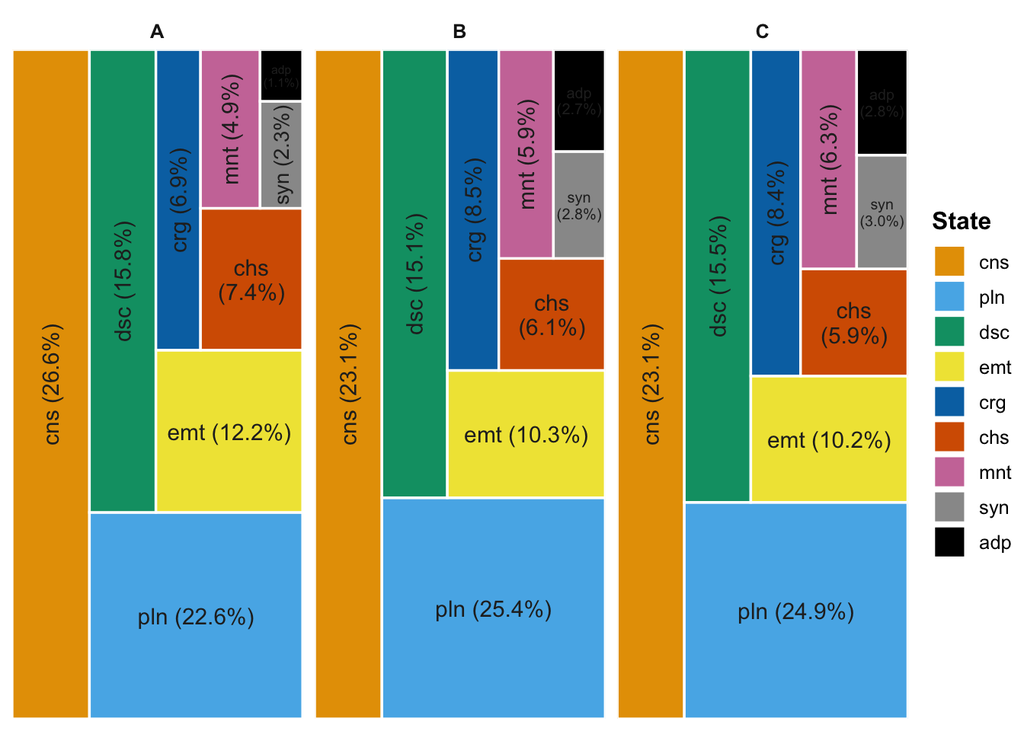

```r
plot_state_frequencies(
  course_net,
  label = "all",
  abbreviate = TRUE,
  legend = "right"
)
```

# MCML State Frequencies

The function also dispatches on `mcml`. Each within-cluster layer becomes a panel.

```
#> State frequencies (style = marimekko, source = mcml)
#>   Total events: 27,533  |  Groups: 3  |  States: 9
#>
#> Per-group totals
#>     group          events  share
#>     Cognition      11,793  42.8%
#>     Metacognition   8,693  31.6%
#>     Social          7,047  25.6%
#>
#> Per-state proportions (within group)
#>     group          state       count  share
#>     Cognition      consensus   6,797  57.6%
#>     Cognition      discuss     4,267  36.2%
#>     Cognition      synthesis     729  6.2%
#>     Metacognition  plan        6,623  76.2%
#>     Metacognition  monitor     1,516  17.4%
#>     Metacognition  adapt         554  6.4%
#>     Social         emotion     3,075  43.6%
#>     Social         coregulate  2,133  30.3%
#>     Social         cohesion    1,839  26.1%
```

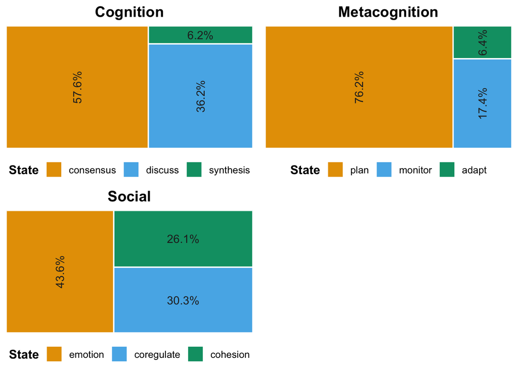

```r
clusters <- list(
  Cognition = c("discuss", "synthesis", "consensus"),
  Metacognition = c("plan", "monitor", "adapt"),
  Social = c("coregulate", "cohesion", "emotion")
)

mc <- build_mcml(
  group_regulation_long,
  clusters = clusters,
  method = "sum",
  type = "frequency",
  actor = "Actor",
  time = "Time",
  action = "Action"
)

plot_state_frequencies(mc)
```

```r
state_distribution(mc)
```

| group | state | count | proportion |
| --- | --- | --- | --- |
| Cognition | consensus | 6797 | 0.57635886 |
| Cognition | discuss | 4267 | 0.36182481 |
| Cognition | synthesis | 729 | 0.06181633 |
| Metacognition | plan | 6623 | 0.76187737 |
| Metacognition | monitor | 1516 | 0.17439319 |
| Metacognition | adapt | 554 | 0.06372944 |
| Social | emotion | 3075 | 0.43635590 |
| Social | coregulate | 2133 | 0.30268199 |
| Social | cohesion | 1839 | 0.26096211 |

# Chi-square Mosaics

`mosaic_plot()` requires integer-valued weights. Use `method = "frequency"` for transition counts.

```r
data(ai_long)

ai_counts <- build_network(
  ai_long,
  method = "frequency",
  action = "code",
  actor = "session_id",
  time = "order_in_session"
)

ai_counts
```

```
#> Transition Network (frequency counts) [directed]
#>   Weights: [1.000, 1575.000]  |  mean: 126.922
#>
#>   Weight matrix:
#>               Ask Delegate Execute Explain Investigate Plan Repair Report
#>   Ask           3        3      26      44           9    3      2      1
#>   Delegate      2        7      51      14          26  174      4      2
#>   Execute      32       69    1575     169         762  358     93     32
#>   Explain      10        8     129      66         158   35     42     56
#>   Investigate  21       36     563      79         493  977     40     26
#>   Plan         15       73     709      90         458   49     60     56
#>   Repair       13       10     119      43          59    4      2      1
#>   Report        1       10      61      18          46    5     14      7
#>
#>   Initial probabilities:
#>   Investigate   0.715  ████████████████████████████████████████
#>   Delegate      0.185  ██████████
#>   Execute       0.058  ███
#>   Plan          0.035  ██
#>   Ask           0.005
#>   Explain       0.002
#>   Repair        0.000
#>   Report        0.000
```

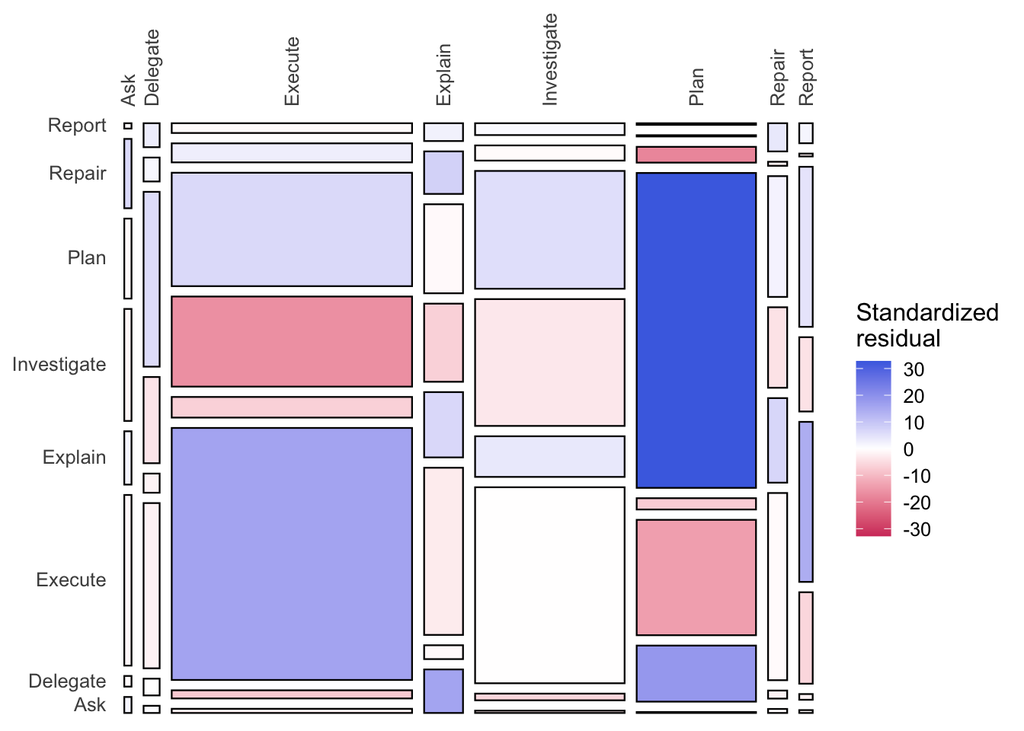

```r
mosaic_plot(ai_counts, seed = 1)
```

In this plot, area is tied to count structure and color is the standardized residual:

- blue: more transitions than expected;
- red: fewer transitions than expected;
- white: close to expected.

Permutation residuals are the default.

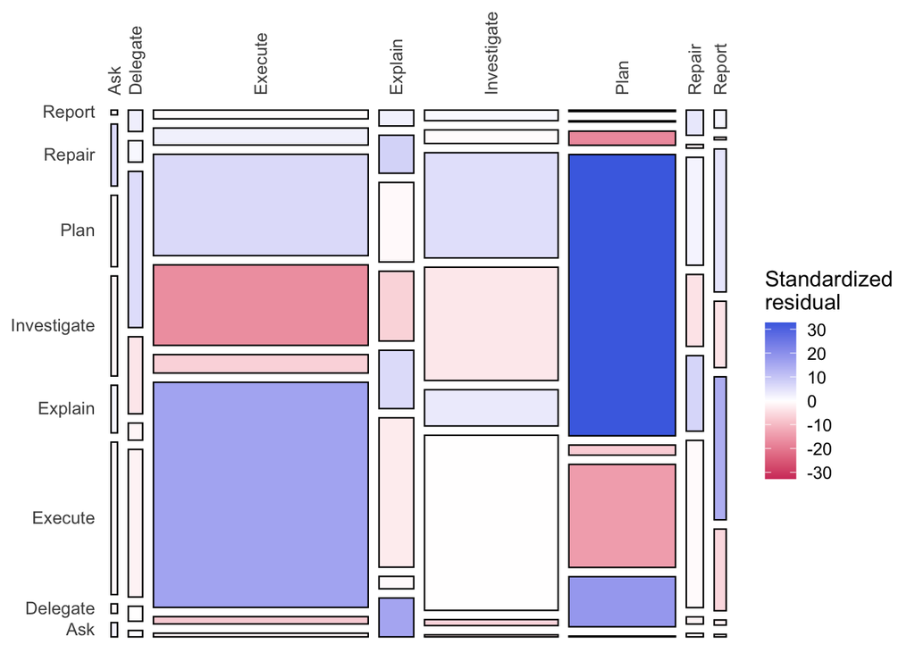

```r
mosaic_plot(ai_counts, residuals = "permutation", n_perm = 1000, seed = 1)
```

Use asymptotic residuals when comparing with tools based on `chisq.test()$stdres`.

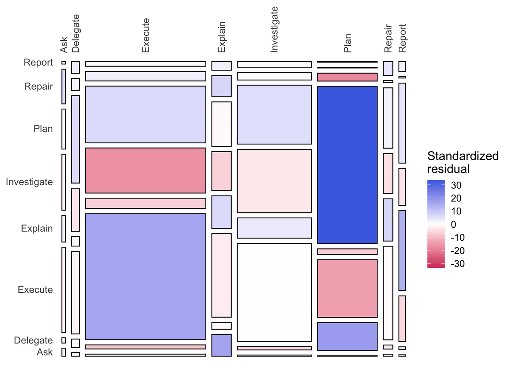

```r
mosaic_plot(ai_counts, residuals = "asymptotic")
```

Clip the color range when an extreme residual compresses the rest of the scale.

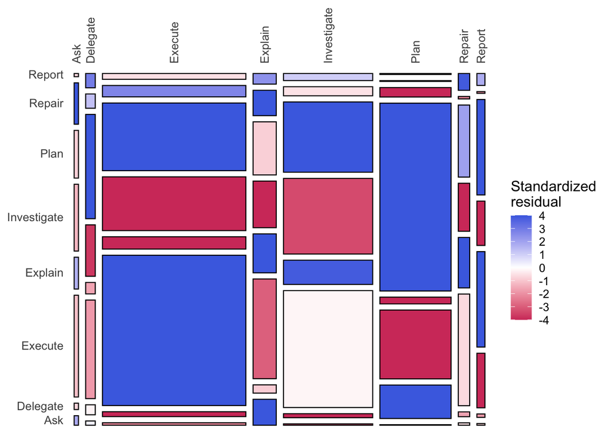

```r
mosaic_plot(ai_counts, range = c(-4, 4), seed = 1)
```

# Group Mosaics

For `netobject_group`, `mosaic_plot()` builds one joint group-by-state mosaic.

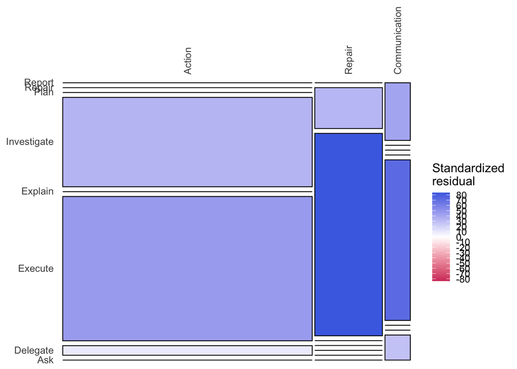

```r
ai_group_counts <- build_network(
  ai_long,
  method = "frequency",
  action = "code",
  actor = "session_id",
  time = "order_in_session",
  group = "cluster"
)

mosaic_plot(ai_group_counts, seed = 1)
```

This plot asks whether groups distribute differently across states. It is not one transition matrix per group.

# MCML Mosaics

The macro view shows cluster-to-cluster count residuals.

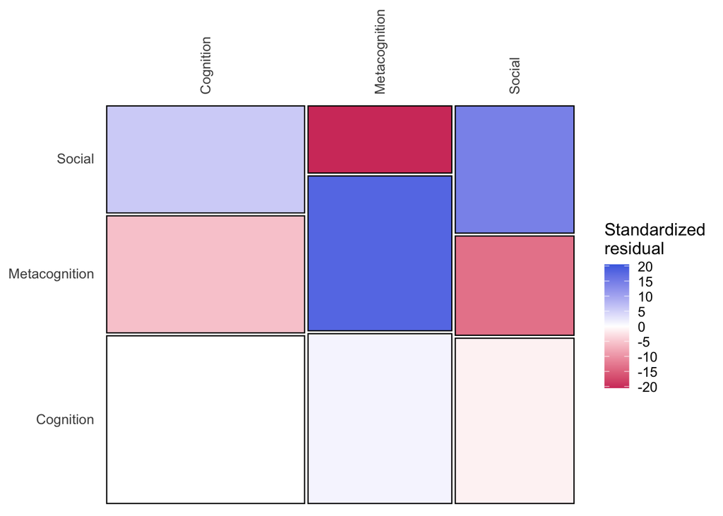

```r
mosaic_plot(mc, level = "macro", seed = 1)
```

The cluster view shows one within-cluster mosaic per cluster.

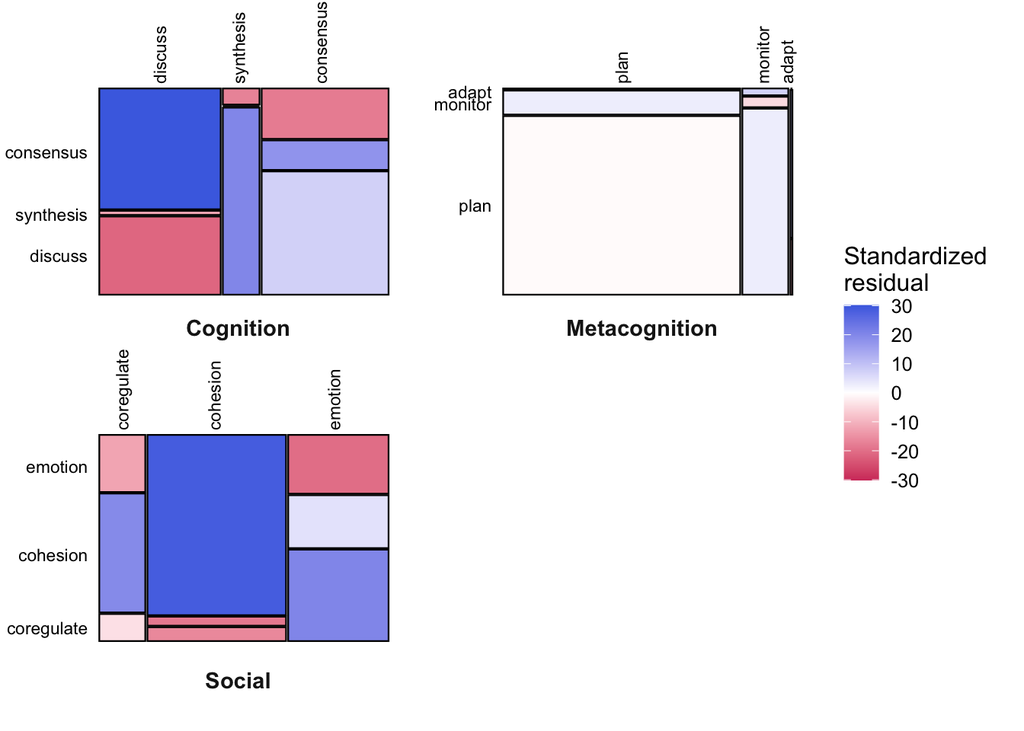

```r
mosaic_plot(mc, level = "clusters", seed = 1)
```

# Choosing the Plot

Use `plot_state_frequencies()` for composition. Use `mosaic_plot()` for residuals from count tables. If the network is row-normalized, use frequencies or counts before making a mosaic.